# Reproduction of results

# Overview

This document provides a step-by-step guide to reproduce the results of the paper [“Multi-view biclustering via non-negative matrix tri-factorisation”](https://arxiv.org/abs/2502.13698). This webpage is generated from the `reproduce_results.rmd` file in the `resNMTF_paper` GitHub repository. It is designed to be run on a local MacOS/linux machine with **R**, **Python** and a **shell language** available.

Details on how to run the file and reproduce the results are provided below. To begin, some details on setup and requirements are provided.

## Which results are reproduced here?

Due to the extensive number of simulation studies, we have only included the code to reproduce the results for those in the main body of the text. Further instructions to reproduce the results for those in the supplementary material are detailed at relevant points in the document. All figures included in the poster for the **Bioinference 2025 conference** are from the main body of the paper and as such are reproduced here.

All figures included in this webpage are generated by the preceeding code chunk.

**Note:** Due to long run times several modifications have been made:

1. The simulation studies were run with 100 repetitions, this has been changed to 3 repetitions. To run with the full number of repetitions, simply change the `n_reps` parameter in the relevant code chunk. Each repeat adds just over an hour to the run time.
2. The code chunks to reproduce the results on the real data (which take substantially longer to run (at least a day each) than the simulations) have been set to `eval=FALSE` and `include=FALSE` to prevent the code from running. To reproduce these results anyway, simply remove these two arguments.

The runtime for this document (on a 2024 M4 Macbook Pro with 16GB RAM) without the real data applications is approximatley **3.5 hours**. The runtime for the each real data applications is approximately 1-2 days (on a cluster).

Any figures from the paper that are not produced by code (i.e. illustrations) are not included in this document.

## Document structure

The document is structured as follows:

- **Setup**: This section details the software and packages required to run the code. It also includes instructions on how to set up the environment.
- **Results**: This section details the code to reproduce the results in the paper. It is divided into three sections: Simulation studies, Real data applications and Additional figures. Each subsection contains the code to reproduce the relevant results.

# Setup

This section details the software required to run the code and includes details to install relevant packages as well as set up required environments.

As the code was developed using shell scripts, a shell language is required. If you are on Windows, please install a `zsh` shell (e.g. [Git Bash](https://gitforwindows.org/) or [Cygwin](https://www.cygwin.com/)).

**Important:** The following assumes you are using a `zsh` shell. If you are using a different shell, please adjust the commands in the code chunks accordingly.

### R

#### 1. Clone the repository

In order to run this document, you need clone the github repository to your local machine, and knit the `reproduce_results.rmd` file. The repository can be found [here](https://github.com/eso28599/resNMTF_paper).

#### 2. Install R packages

Secondly, we need to install the required packages. The `resnmtf` and `bisilhouette` packages are available on github and can be installed using the `devtools` package. This work requires our `R` packages `resnmtf` and `bisilhouette`, the github pages for which can be found [here](https://eso28599.github.io/resnmtf/) and [here](https://eso28599.github.io/bisilhouette/) respectively.

```r
# Install and load required packages
source("install_packages.r")
library(devtools)
devtools::install_github("eso28599/resnmtf")
devtools::install_github("eso28599/bisilhouette")
library(resnmtf)
library(bisilhouette)
library(knitr)
library(magick)
```

### Python

As one of the methods ResNMTF is compared against a method written in Python, an environment is provided for reproducibility. This assumes you have python and pip available on your machine. If you do not, please install them.

#### Conda environment installation (default)

```bash
chmod +x ./conda_env.sh
source conda_env.sh
```

#### Pip environment installation

Alternatively, if you do not have conda installed, you can create a virtual environment using `pip`. This can be done by changing eval running the following code chunk.

If you don’t have `pyenv` installed, please install it following instructions [here](https://github.com/pyenv/pyenv). This allows you to create a virtual environment with a specific version of Python, which is needed to run the iSSVD method.

```bash
chmod +x ./virtual_env.sh
./virtual_env.sh
```

You will also need to uncomment the `source` line in the `SimStudy/run_sim.sh` file to activate the environment using `pip` rather than `conda`.

# Results

This section details the code to reproduce all results from the paper, with each code chunk corresponding to a figure or table in the paper. All figures included in this document are generated by the preceeding code chunk.

## Simulation studies

### Figure 4

#### (A-B) Increasing number of biclusters

To run the simulation study for increasing the number of biclusters (on the base scenario of three views), with **3 repeats**, the following code chunk can be used:

```bash
export sim="bicl"
export sim_folder_name="bicl_3v"
export seq=(3 4 5 6)
export n_reps=3
./SimStudy/run_sim.sh $sim $sim_folder_name $n_reps $seq
```

**Tip:** The full results produced can now be found in the `SimStudy/Results/bicl_3v` folder, individually under various file names (`F_score_plot.pdf`, `BiS_plot.pdf`, etc.) or in one pdf (`results.pdf`).

Some of the results produced are shown below:

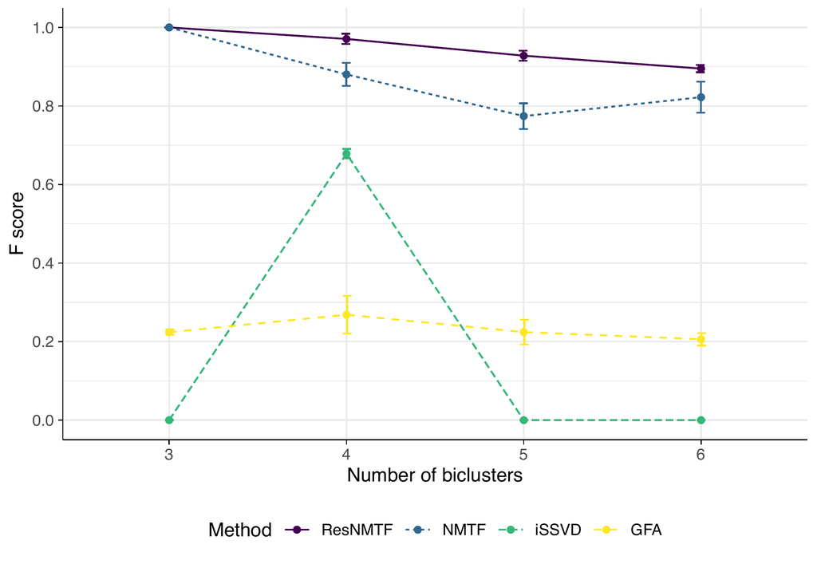

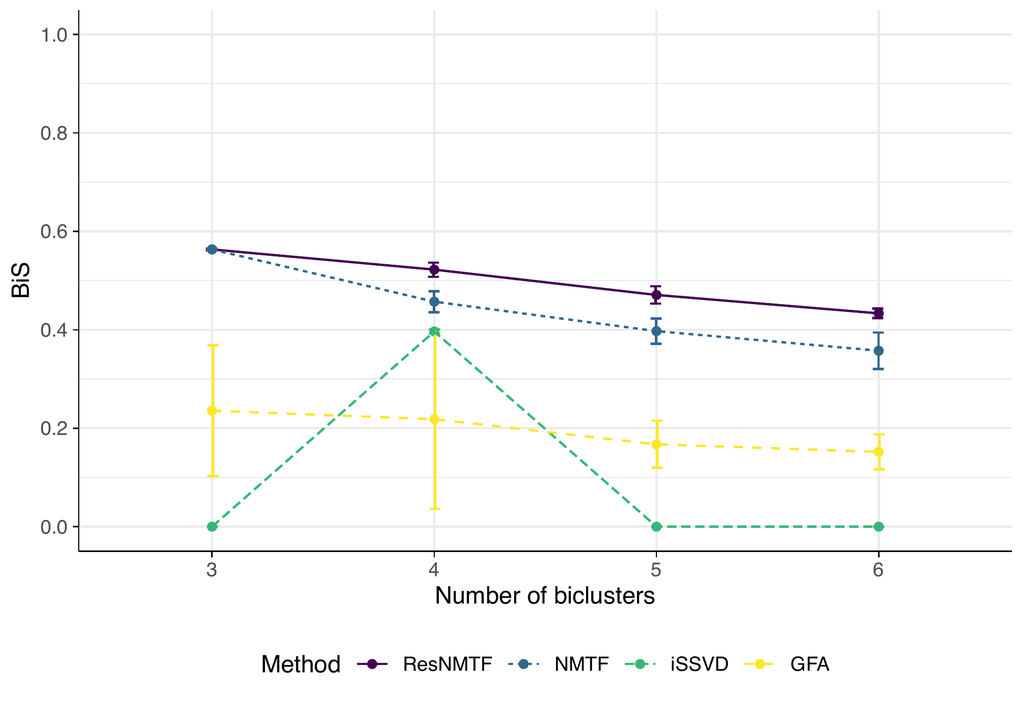

- (C-D) Increasing number of views: `views`, `views_5b`, `2 3 4 5`
- (E-F) Increasing number of individuals: `indiv`, `indiv_3v5b`, `50 200 300 500 1000`
- (G-H) Increasing level of noise: `noise`, `noise_3v5b`, `1 2 3 4 5 6 7 8 9 10 20 30 40 50 60 70 80 90 100`

The variable names for remaining experiments are detailed in the readme file.For a specific simulation, the `seq` variable is found in the corresponding `SimStudy/Scripts/[sim_folder_name]_script_one.sh` file, in the for loop.

**Note:** The experiments were initially run on clusters, the scripts to run the simulations on clusters can be found in the `SimStudy/Scripts` folder where each experiment has a `[sim_study]_script_one.sh` and a`[sim_study]_script_two.sh` file.